# Analyse du corpus Kommersant 2020-2021

Aleksandra Zemlianaia

2025-03-04

## Introduction

Dans ce document, je vous présente le processus et les résultats de la première analyse du corpus des articles de l’édition Kommersant. Il s’agit d’un journal proche du gouvernement qui publie beaucoup d’articles sur les sujets économiques et socio-politiques. J’ai choisi d’ajouter ce journal à mon corpus de presse afin de comparer le ton et les sujets des publications de médias plutôt opposés au gouvernement à ceux exprimant un soutien à l’État.

L’analyse présentée dans ce document est basée sur la première partie du corpus des articles de Kommersant. Au final, je prévois de collecter toutes les publications du journal sur le thème de la crise démographique, de la diminution du nombre des naissances et de ses conséquences, ainsi que de la politique démographique du gouvernement du début de l’année 2020 jusqu’à janvier 2025. Il s’est avéré que Kommersant publie beaucoup d’articles sur ce sujet. C’est pourquoi j’ai formé le corpus des publications 2020-2021 que je vais décrire dans la partie suivante.

## Présentation du corpus 2020-2021

```r
library(R.temis)
library(dplyr)
corpus <- R.temis::import_corpus("C:/rdocs/Kommersant1.txt", format="alceste", language="russian")

meta_no_date <- meta(corpus)[, !(names(meta(corpus)) %in% "Date")]
print(meta_no_date)
```

```
##    num   an quart presse        titre        texte
## 1    1 2020     1    kom       neutre       neutre
## 2    2 2020     1    kom       neutre       neutre
## 3    3 2020     1    kom     ironique     critique
## 4    4 2020     1    kom       neutre       neutre
## 5    5 2020     1    kom enthousiaste enthousiaste
## 6    6 2020     1    kom       neutre     critique
## 7    7 2020     1    kom     ironique       neutre
## 8    8 2020     1    kom       neutre       neutre
## 9    9 2020     1    kom     ironique     critique
## 10  10 2020     1    kom       neutre       neutre
## 11  11 2020     1    kom    alarmiste    alarmiste
## 12  12 2020     1    kom       neutre       neutre
## 13  13 2020     1    kom       neutre       neutre
## 14  14 2020     1    kom     ironique       neutre
```

[output cut: 33 more lines]

Le tableau ci-dessus montre les méta-données du corpus :

```
- année de publication (2020 ou 2021);
- quartile de publication
    (1 = janvier, fevrier, mars;
     2 = avril, mai, juin;
     3 = juillet, août, septembre;
     4 = octobre, novembre, décembre);
- journal de publication (Kommersant pour tous ces articles);
- tonalité du titre
    (enthousiaste / neutre / ironique / critique / alarmiste);
- tonalité du texte entier
    (enthousiaste / neutre / ironique / critique / alarmiste).
```

Les deux dernières variables sont nouvelles par rapport à l’essai d’analyse réalisé en décembre. J’espère pouvoir les utiliser pour une analyse quantitative et comparative par journal et par an. Dans ce corpus, on pourrait explorer si les tonalités du titre et du texte coïncident dans les publications de Kommersant et s’il y a eu un changement global dans les tonalités durant les deux années étudiées.

## Premier regard sur les métadonnées

```r
library(questionr)
freq(meta(corpus)$an)
```

```
##       n    % val%
## 2020 30 63.8 63.8
## 2021 17 36.2 36.2
```

Tout d’abord, il faut mentionner que deux tiers des articles de ce corpus ont été publiés en 2020. La lecture des publications et le début de l’analyse qualitative ont démontré que ce boom de publications est dû à l’introduction du capital maternel pour la naissance des premiers enfants (alors qu’à l’époque le versement monétaire était réservé à la naissance des dexuièmes enfants) et aux données statistiques sur les conséquences démographiques de la pandémie de la covid-19. L’analyse des fréquences permettra de déterminer si ces sujets apparaissent parmi les mots les plus utilisés.

```r
freq(meta(corpus)$quart)
```

```
##    n    % val%
## 1 22 46.8 46.8
## 2  8 17.0 17.0
## 3  5 10.6 10.6
## 4 12 25.5 25.5
```

Sinon, ce qui saute aux yeux et diffère ce corpus de celui de la France, c’est la variété des quartiles de publications. Alors que les médias français que j’analyse publient des articles sur les sujets démographiques au début de l’année, quand le bilan démographique sort, ou vers la fin de l’année, pour parler des tendances globales, le journal Kommersant suit le sujet de la natalité tout au long de l’année. Évidemment, les publications des premiers et quatrièmes quartiles sont plus nombreuses, mais huit publications au printemps et cinq en été sont étonnantes pour moi. Pour le moment, je ne suis pas sûre qu’il y ait des thèmes spécifiques à chaque saison. Je fais cependant l’hypothèse qu’il pourrait y en avoir quelques-uns, parce que c’est une tendance logique dans d’autres sujets, par exemple dans l’éducation, où il y a toujours une hausse de publications en saison des examens et de l’entrée à l’université.

```r
freq(meta(corpus)$titre)
```

```
##               n    % val%
## alarmiste     7 14.9 14.9
## enthousiaste  4  8.5  8.5
## ironique     10 21.3 21.3
## neutre       26 55.3 55.3
```

La moitié des articles présente des titres plutôt neutres. Ils parlent d’un nouveau projet gouvernemental ou de la mise en vigueur d’une mesure déjà annoncée. 20 % des articles ont des titres plutôt ironiques, dans lesquels les journalistes se moquent de l’alarmisme des politiciens ou font des jeux de mots autour des mesures de la politique sociale et des proverbes sur la famille. D’après mes observations, l’article dont le titre est ironique s’avère souvent plutôt neutre au niveau des arguments.

Les titres marqués comme enthousiastes expriment de la joie envers des mesures prises par le gouvernement ou manifestent une bonne tendance démographique. Mon exemple préféré : « En Russie, la diminution de natalité a ralenti ». Même si le phénomène est toujours considéré comme négatif, l’auteur cherche ici à présenter une bonne nouvelle. Les titres alarmistes sont plus rares, mais tous très marquants : « On a prédit une diminution de la population… » ou bien « L’éducation et les contraceptifs conduiront l’humanité à la mort ». Les articles portant des titres alarmistes se montrent tout aussi anxieux dans le texte.

```r
freq(meta(corpus)$texte)
```

```
##               n    % val%
## alarmiste     7 14.9 14.9
## critique      6 12.8 12.8
## enthousiaste  2  4.3  4.3
## neutre       32 68.1 68.1
```

Le tableau de distribution des articles selon la tonalité du texte montre qu’il y a plus d’articles neutres que de titres. En même temps, le nombre de textes alarmistes est égal à celui des titres alarmants. La tonalité ironique n’est pas du tout présente dans la distribution des textes, même s’il y avait 10 titres ironiques dans ce corpus. La tonalité « critique » apparaît dans 6 textes, mais je n’ai rencontré aucun titre qui pourrait être qualifié ainsi.

Il faut également mentionner que l’attribution de ces catégories de tonalité est plutôt subjective et basée sur ma perception du sujet, sur l’impression que me laissent le titre et le texte. J’ai donc considéré comme textes alarmistes non seulement ceux où le journaliste utilise des expressions alarmistes, mais aussi ceux où le journaliste adopte une position plus neutre tout en citant de nombreux témoignages alarmants. En somme, le texte laisse une impression anxieuse au lecteur. Une telle approche de classification reste à discuter.

Après avoir jeté un premier coup d’œil sur les métadonnées, passons à l’analyse des fréquences des mots.

## Fréquences des mots

```r
tablex <-build_dtm(corpus, remove_stopwords = T )
tablex
```

```
## <<DocumentTermMatrix (documents: 47, terms: 5869)>>
## Non-/sparse entries: 11426/264417
## Sparsity           : 96%
## Maximal term length: 23
## Weighting          : term frequency (tf)
```

Donc, le corpus contient 47 documents de presque six milles de mots au total. J’ai ajouté l’argument pour éliminer les mots inutiles, voyons s’il va marcher pour le corpus en russe.

```r
dic <-dictionary(tablex)
word_freq <- colSums(as.matrix(tablex))
word_freq_df <- data.frame(word = names(word_freq), frequency = word_freq)
filtered_words <- word_freq_df[word_freq_df$frequency >= 15, ]
sorted_words <- filtered_words[order(-filtered_words$frequency), ]
print(sorted_words)
```

```
##                            word frequency
## населения             населения       163
## года                       года       145
## это                         это       124
## россии                   россии       118
## году                       году       116
## млн                         млн       102
## ребенка                 ребенка        92
## тыс                         тыс        92
## детей                     детей        91
## рождаемости         рождаемости        81
## лет                         лет        79
## руб                         руб        75
## семей                     семей        66
## капитала               капитала        54
## также                     также        47
## рф                           рф        45
## число                     число        44
## материнского       материнского        42
## поддержки             поддержки        42
## семьи                     семьи        38
## стране                   стране        37
## возраста               возраста        35
## детьми                   детьми        35
## смертности           смертности        35
## численность         численность        35
## которые                 которые        33
## убыль                     убыль        33
## женщин                   женщин        32
## меры                       меры        32
## население             население        31
## рождения               рождения        31
## жизни                     жизни        30
## млрд                       млрд        30
## например               например        30
## рождаемость         рождаемость        30
## вице                       вице        28
## страны                   страны        28
## выплаты                 выплаты        27
## капитал                 капитал        27
```

[output cut: 68 more lines]

```
## согласно               согласно        16
## сокращение           сокращение        16
## социальной           социальной        16
## татьяна                 татьяна        16
## трлн                       трлн        16
## увеличение           увеличение        16
## этих                       этих        16
## возрасте               возрасте        15
## второй                   второй        15
## маткапитал           маткапитал        15
## наиболее               наиболее        15
## образом                 образом        15
## пандемии               пандемии        15
## пресс                     пресс        15
## среди                     среди        15
```

L’argument pour éliminer les mots inutiles a marché, ce qui est très bien ! J’ai gardé dans cette liste les mots qui apparaissent plus de 15 fois dans le corpus entier, sortis en décroissance de la popularité des mots. Au total, 122 mots répondent à cette condition et ne sont pas des prépositions ou des conjonctions. Pourtant, à cette étape, les différentes formes d’un seul mot sont comptées comme des mots différents. Le mot le plus fréquemment utilisé est « la population » en deuxième déclinaison, donc utilisé pas comme le sujet, mais comme un complément d’objet.

Il y a aussi beaucoup d’acronymes dans cette liste (comme « руб » au lieu de « рубли »), je vais maintenant créer un filtre pour les éliminer et ensuite former un nuage de mots avec ceux qui restent.

## Nuage des mots

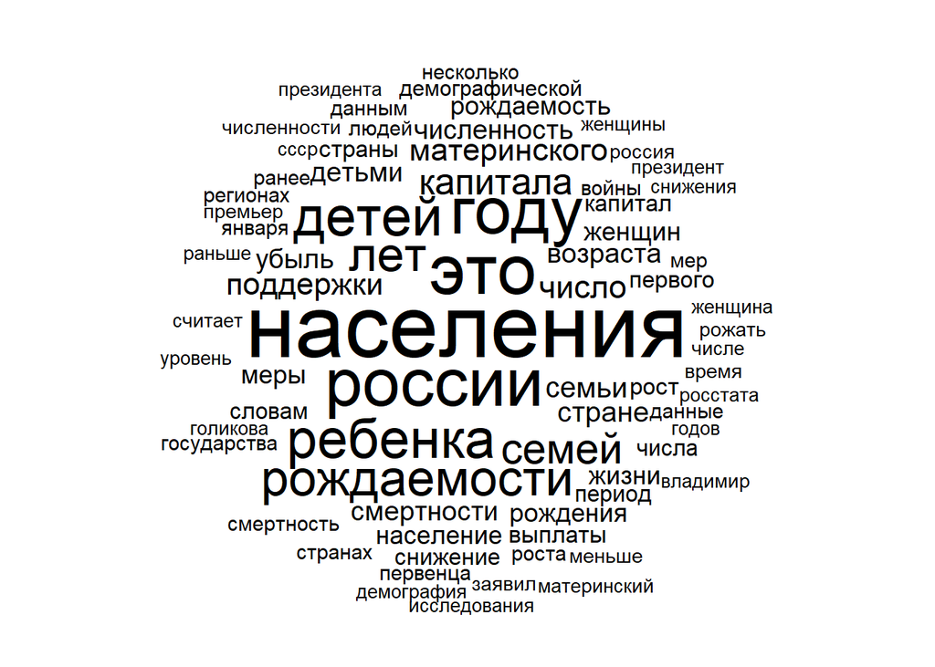

```r
asupp <- c("млн", "тыс", "руб", "также", "рф", "млрд", "вице", "около", "однако", "очень", "могут", "пока", "будут", "какие", "которых", "аси", "случае", "трлн", "этих", "этих", "пресс", "среди", "годы", "года", "которые", "хотя", "например", "согласно", "рождений", "рождении", "год")
tablex2 <-tablex[, !colnames(tablex)  %in% asupp]
cloud<-word_cloud(tablex2, n=100, min.freq=17)
```

Voici le nuage de mots obtenu après l’élimination des mots inutiles et de certaines formes de mots en déclinaison (j’ai aussi relevé le seuil de fréquences pour 17 mots).

Première conclusion qui ressort de ce schéma : les mots liés au thème du covid ne sont pas significativement présents dans les textes du corpus. Même si le sujet est souvent abordé dans les titres, les mots comme « pandémie » ou « covid » ne figurent pas souvent dans les textes du corpus. Le capital maternel, au contraire, apparaît dans la liste des mots les plus utilisés.

Sur l’image suivante, je cherchais à diviser ces mots en groupes que je vais ensuite décrire (attention, l’image est un peu trop grande et peut faire peur).

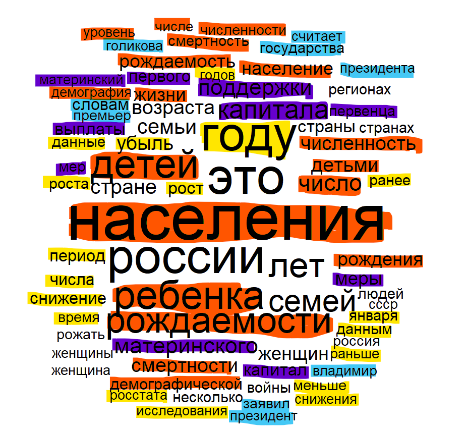

```r
knitr::include_graphics("C:/rdocs/wordcloud.png")
```

Le premier groupe **en rouge** est le plus nombreux et contient des mots pour parler des données et des processus démographiques tels que « population », « natalité », « mortalité », mais aussi des termes plus spécifiques comme « niveau de vie », « nombre d’enfants », « nombre de naissances ». Le mot « population » est le plus fréquemment utilisé dans les textes de ce corpus.

Le deuxième groupe **en jaune** est formé de mots qui servent à décrire des statistiques : « décroissance », « moins », « réduction » contre « croissance » (en deux déclinaisons). Ainsi, le mot « croissance » apparaît plus souvent dans le corpus (49 fois sous toutes ses formes) mais l’idée de diminution est présentée en expressions différentes et revient plus souvent finalement (96 fois tous les mots liés compris).

Le troisième groupe **en violet** est entièrement consacré aux mesures de soutien aux familles mises en place par le gouvernement. Les mots clés sont « soutien », « mesures », « capital maternel ». La notion de ce dernier apparaît 81 fois. On pourrait donc considérer ce thème comme central pour le corpus exploré.

Pour le quatrième groupe **en bleu** j’ai choisi les mots qui signalent une référence à un témoignage. Si, dans le corpus exploratif français, les mots du groupe similaire étaient des verbes déclaratifs, dans le corpus de Kommersant, ce sont principalement des postes et des noms de politiciens. On y trouve notamment « Président » (aux deux déclinaisons), « Vladimir », « vice-premier ministre », « Golikova » (premier ministre en politique sociale) et « l’État » en général. Ce moment est vraiment marquant, car il montre l’omniprésence du discours gouvernemental dans les articles de Kommersant. Le journal publie beaucoup d’annonces des mesures gouvernementales qui sont entièrement consacrées aux actions et paroles des politiciens, mais même dans des articles non liés aux discours gouvernementaux, les journalistes citent Tatiana Golikova ou le président Poutine.

Finalement, les mots que je n’ai pas réunis dans un groupe sont d’abord les déclinaisons des mots « femme » et « famille ». On pourrait dire que leur utilisation est neutre par rapport au thème de la natalité. Pourtant, dans le corpus français, ces deux mots étaient accompagnés du mot « père » qui n’apparaît pas dans le corpus de Kommersant. On constate que le sujet démographique est plutôt considéré comme un sujet féminin et que la participation des hommes n’est pas prise en considération. Les mots qui restent appartiennent au domaine géographique : « Russie », « d’autres pays », « régions ». Dans les articles de ce corpus, la Russie est souvent comparée à d’autres pays européens pour évaluer les tendances démographiques en tenant compte de la situation démographique globale dans le monde. Les autres pays apparaissent aussi dans des articles où les experts ou les politiciens cités utilisent l’exemple d’un autre pays pour proposer une nouvelle politique familiale (les pays les plus cités en ce sens sont la France et la Suède).